# Working with canpumf

```r
library(dplyr)
library(tidyr)
library(ggplot2)
library(canpumf)
options(canpumf.cache_path = Sys.getenv("COMPILE_VIG_CANPUMF"))
```

The Canadian Housing Survey PUMF data is a rich dataset on Canadian housing preferences and needs. This vignette is adapted from [work done by Nathan Lauster and Jens von Bergmann](https://doodles.mountainmath.ca/blog/2021/03/29/forced-out-in-canada-new-data-from-chs/). We start by establishing a connection to the 2018 CHS, downloading the data, parsing the metadata and creating the local database if needed.

```r
chs_pumf <- get_pumf("CHS","2018")

chs_pumf |>
  select(1:5) |>
  head(10)
```

```
#> # A query:  ?? x 5
#> # Database: DuckDB 1.5.4 [root@Darwin 27.0.0:R 4.6.0//Users/jens/data/pumf.data/CHS/2018/CHS_2018.duckdb]
#>    PUMFID PHHSIZE PAGEGR1 PAGEGR2 PAGEGR3
#>    <chr>  <fct>   <fct>   <fct>   <fct>
#>  1 00001  1       No      No      No
#>  2 00002  1       No      No      Yes
#>  3 00003  1       No      No      No
#>  4 00004  1       No      No      No
#>  5 00005  1       No      No      No
#>  6 00006  1       No      No      No
#>  7 00007  4       Yes     Yes     Yes
#>  8 00008  2       No      No      Yes
#>  9 00009  1       No      No      Yes
#> 10 00010  4       No      Yes     Yes
```

The data comes automatically labelled, but column names are left as coded in the data. That makes it easier to work with the data if one is very familiar with the particular survey, but can also be a barrier. In that case one can apply column labels on the fly.

```r
chs_pumf <- chs_pumf |>
  label_pumf_columns()

chs_pumf |>
  select(1:5) |>
  head(10)
```

```
#> # A query:  ?? x 5
#> # Database: DuckDB 1.5.4 [root@Darwin 27.0.0:R 4.6.0//Users/jens/data/pumf.data/CHS/2018/CHS_2018.duckdb]
#>    `Unique household identifier` `Household size` Demographic information - ag…¹
#>    <chr>                         <fct>            <fct>
#>  1 00001                         1                No
#>  2 00002                         1                No
#>  3 00003                         1                No
#>  4 00004                         1                No
#>  5 00005                         1                No
#>  6 00006                         1                No
#>  7 00007                         4                Yes
#>  8 00008                         2                No
#>  9 00009                         1                No
#> 10 00010                         4                No
#> # ℹ abbreviated name: ¹`Demographic information - age group: 0 - 17`
#> # ℹ 2 more variables: `Demographic information - age group: 18 - 29` <fct>,
#> #   `Demographic information - age group: 30 - 64` <fct>
```

Applying column labels can make selecting columns more tedious, but can also avoid downstream errors in the analysis.

## Label repair

The labels that come out of StatCan’s command files are frequently **truncated** — cut at a fixed width, or missing their leading text. Where the survey’s user guide ships a data-dictionary appendix, `canpumf` parses it and repairs the labels automatically, so most of the time there is nothing to do. Because that appendix prints the frequency of every code, the scrape is first reconciled against the actual microdata, and a label is only ever replaced when the guide’s text demonstrably extends the command file’s *and* the command file shows the fingerprint of truncation. Nothing is repaired silently:

```r
# what the cross-check concluded about this survey's data
table(pumf_freq_validation(chs_pumf)$status)
```

```
#> < table of extent 0 >
```

```r
# every divergence found, repaired or not
pumf_label_repairs(chs_pumf) |> head()
```

```
#> # A tibble: 0 × 9
#> # ℹ 9 variables: kind <chr>, name <chr>, val <chr>, lang <chr>,
#> #   label_command_file <chr>, label_pdf <chr>, action <chr>, reason <chr>,
#> #   validation <chr>
```

Both return zero rows here — the CHS ships no user-guide appendix, so there is nothing to cross-check against. Surveys that do carry one, such as GSS Cycle 16, look very different:

```r
gss <- get_pumf("GSS", "Cycle 16 (2002)")

pumf_label_repairs(gss, action = "repaired") |>
  select(name, label_command_file, label_pdf)
```

```
#> # A tibble: 1,679 x 3
#>   name      label_command_file                                            label_pdf
#>   ACMPRYR_C "During the past 12 months, was your spouse's/partner's main"  "During the past 12 months, was your spouse's/partner's main activity working at a paid job or business, looking for paid work, going to school, caring for children, household work, retired or something else?"
#>   ...
```

The command file cut that one at 60 characters, mid-phrase — which is the shape the ceiling test looks for.

`action = "flagged"` gives the divergences that were recorded but deliberately *not* acted on — most usefully, places where the guide and the command file genuinely disagree rather than one being a truncation of the other. The whole step needs the `pdftools` package and can be turned off with `options(canpumf.pdf_crosscheck = FALSE)`.

## Forced moves

We take a simple look at the share of current renters that were forced to move on their most recent move, keyed by when the most recent move occurred. To estimate risk of being forced to move we look at all current renters that did not move in the five years prior to the CHS, or those that moved in the prior five years and were renters in their old accommodation, as a base and ask what share of these were forced to move in a given timeframe.

```r
renter_chs_pumf <- chs_pumf |>
  filter((Tenure == "No" &
            `Previous accommodations - when move to current dwelling occurred` == "10 or more years ago + Always lived here") |
           (`Previous accommodations - when move to current dwelling occurred` != "10 or more years ago + Always lived here" &
              `Previous accommodations - tenure`== "Rent it"))
```

We will also focus on people that did move in the past 5 years, as recall bias might make data from longer timeframes less reliable and the reported time windows get large.

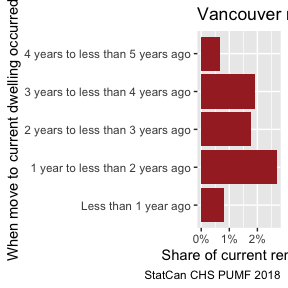

```r
plot_data <- renter_chs_pumf |>
  filter(`Geographic grouping`=="Vancouver") |>
  group_by(`Previous accommodations - when move to current dwelling occurred`,
           `Previous accommodations - forced to move`) |>
  summarise(value=sum(`Household weight`),.groups = "drop") |>
  mutate(share=value/sum(value)) |>
  filter(`Previous accommodations - forced to move`=="Yes",
         !grepl("10",`Previous accommodations - when move to current dwelling occurred`))


ggplot(plot_data,aes(x=`Previous accommodations - when move to current dwelling occurred`,y=share)) +
  geom_bar(stat="identity",fill="brown") +
  coord_flip() +
  scale_y_continuous(labels=scales::percent) +
  labs(title="Vancouver renters forced to move",
       x="When move to current dwelling occurred",
       y="Share of current renters",
       caption="StatCan CHS PUMF 2018")
```

This looks interesting in that there seem to be distinct periods when the frequency of being forced to move changed, recognizing that longer ago brackets are conditional on not having moved after.

With PUMF data we need to be aware that we are dealing with a synthetic sample that has been altered from the original survey responses for privacy reasons. With that, and the general uncertainty when dealing with survey data, it is important to assess how good these estimates are. Some PUMF data ship with bootstrap weights to facilitate this, when this is not the case the **canpumf** package fills the gap via the `add_bootstrap_weights` function. By default it adds 500 bootstrap weights. The function can act on a database connection or a tibble. If it’s a database connection, then the weights get stored in the database by default and will be re-used on subsequent calls without the need to re-generate them.

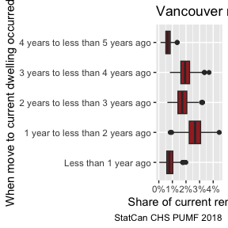

```r
plot_data <- renter_chs_pumf |>
  add_bootstrap_weights(weight_col = "Household weight", seed=42) |>
  filter(`Geographic grouping`=="Vancouver") |>
  summarise(across(matches("CPBSW\\d+|Household weight"),sum),
            .by=c(`Previous accommodations - when move to current dwelling occurred`,
                  `Previous accommodations - forced to move`)) |>
  collect() |>
  pivot_longer(matches("CPBSW\\d+|Household weight"),names_to="weights") |>
  group_by(weights) |>
  mutate(share=value/sum(value)) |>
  filter(`Previous accommodations - forced to move`=="Yes",
         !grepl("10",`Previous accommodations - when move to current dwelling occurred`))
ggplot(plot_data,aes(x=`Previous accommodations - when move to current dwelling occurred`,y=share)) +
  geom_boxplot(fill="brown") +
  coord_flip() +
  scale_y_continuous(labels=scales::percent) +
  labs(title="Vancouver renters forced to move",
       x="When move to current dwelling occurred",
       y="Share of current renters",
       caption="StatCan CHS PUMF 2018")
```

This shows that the changes in frequency of forced moves are fairly robust to sampling issues. The initial jump and then final reduction in risk of being forced to move are interesting, the final reduction may be due to the strengthening of the residential tenancy act in that timeframe.

Another complication when interpreting the data is that the previous accommodation where current renters were forced to move from may have been in a different metro are. The CHS does have some data on the location of the previous residence, but only note if it was in the same or a different city, not metro area. We can add this variable in to see what effect it has.

[figure not shown]

```r
plot_data <- renter_chs_pumf |>
  add_bootstrap_weights(weight_col = "Household weight", seed=42) |>
  filter(`Geographic grouping`=="Vancouver") |>
  summarise(across(matches("CPBSW\\d+|Household weight"),sum),
            .by=c(`Previous accommodations - when move to current dwelling occurred`,
                  `Previous accommodations - location of previous dwelling`,
                  `Previous accommodations - forced to move`)) |>
  collect() |>
  pivot_longer(matches("CPBSW\\d+|Household weight"),names_to="weights") |>
  group_by(`Previous accommodations - location of previous dwelling`,
           weights) |>
  mutate(share=value/sum(value)) |>
  filter(`Previous accommodations - forced to move`=="Yes",
         !grepl("10",`Previous accommodations - when move to current dwelling occurred`)) |>
  mutate(`Location of previous dwelling` = gsub("\\.\\.\\..+$","",`Previous accommodations - location of previous dwelling`))
ggplot(plot_data,aes(x=`Previous accommodations - when move to current dwelling occurred`,
                     fill=`Location of previous dwelling`,
                     y=share)) +
  geom_boxplot(position="dodge") +
  coord_flip() +
  scale_y_continuous(labels=scales::percent) +
  labs(title="Vancouver renters forced to move",
       x="When move to current dwelling occurred",
       y="Share of current renters",
       caption="StatCan CHS PUMF 2018")
```

One way to contextualize this is to compare it to other Canadian CMAs.

```r
plot_data <- renter_chs_pumf |>
  collect() |>
  add_bootstrap_weights(weight_col = "Household weight", seed=42) |>
  filter(`Geographic grouping` %in% c("Vancouver","Toronto","Montréal","Calgary","Ottawa-Gatineau","Winnipeg")) |>
  group_by(`Previous accommodations - when move to current dwelling occurred`,
           `Previous accommodations - location of previous dwelling`,
           `Geographic grouping`,
           `Previous accommodations - forced to move`) |>
  summarise(across(matches("CPBSW\\d+|Household weight"),sum),.groups="drop") |>
  pivot_longer(matches("CPBSW\\d+|Household weight"),names_to="weights") |>
  group_by(`Previous accommodations - location of previous dwelling`,
           `Geographic grouping`,
           weights) |>
  mutate(share=value/sum(value)) |>
  filter(`Previous accommodations - forced to move`=="Yes",
         !grepl("10",`Previous accommodations - when move to current dwelling occurred`)) |>
  mutate(`Location of previous dwelling` = gsub("\\/town.+$","",`Previous accommodations - location of previous dwelling`))
```

```
#>   Replicate 50 / 500 ...
#>   Replicate 100 / 500 ...
#>   Replicate 150 / 500 ...
#>   Replicate 200 / 500 ...
#>   Replicate 250 / 500 ...
#>   Replicate 300 / 500 ...
#>   Replicate 350 / 500 ...
#>   Replicate 400 / 500 ...
#>   Replicate 450 / 500 ...
#>   Replicate 500 / 500 ...
```

[figure not shown]

```r
ggplot(plot_data,aes(x=`Previous accommodations - when move to current dwelling occurred`,
                     fill=`Location of previous dwelling`,
                     y=share)) +
  geom_boxplot(position="dodge") +
  coord_flip() +
  facet_wrap("`Geographic grouping`") +
  theme(legend.position = "bottom") +
  scale_y_continuous(labels=scales::percent) +
  labs(title="Renters forced to move",
       subtitle="(based on households currently renting that did not move in past 5 years or\nhouseholds that moved in past 5 years that rented their previous dweling)",
       x="When move to current dwelling occurred",
       y="Share of current renters",
       caption="StatCan CHS PUMF 2018")
```

This shows that patterns vary across cities, Calgary’s elevated rate of forced moves in four to five year timeframe may be due to the heating up of the rental market during the boom phase at that time, where rent hikes and lack of rent control may have forced people to move.

This data is worth exploring further, but for the example vignette this will have to do.